# Logistic Regression | python

Group 5: Hongru Fang

## Python Tutorial

This page uses the following packages in python. Please make sure that you can load them before trying to run the examples on this page.

```r
import pandas as pd
import matplotlib.pyplot as plt
import warnings
warnings.filterwarnings("ignore")
import statsmodels.formula.api as smf
import statsmodels.api as sm
from sklearn.linear_model import LogisticRegression
from sklearn.metrics import confusion_matrix
from sklearn.metrics import roc_auc_score
from sklearn.metrics import roc_curve
from sklearn.metrics import classification_report
```

## Importing Data and Data Cleaning

In this tutorial, we use pima data as our datasets. In order to fit package in python. We first divide our model into dependent variable and independent variables. Besides, since all independent variables here are numeric, we do not need to change them into factor. However, when utilizing $sm.Logit()$ in python, it doesn’t include intercept, so we add a new column named intercept in the independent variable. The code is as following:

```r
data=pd.read_csv("pima.txt",
   delim_whitespace=True,
   skipinitialspace=True)
data['intercept'] = 1.0
```

Then we clean the rows whose $bmi$ or $diastolic$ equals 0 with following code:

```r
## Data Cleaning
data = data[data['bmi']>0]
data = data[data['diastolic']>0]
y=data['test']
X=data.drop(['test'], axis=1)
```

## Inplement of Logistic Model

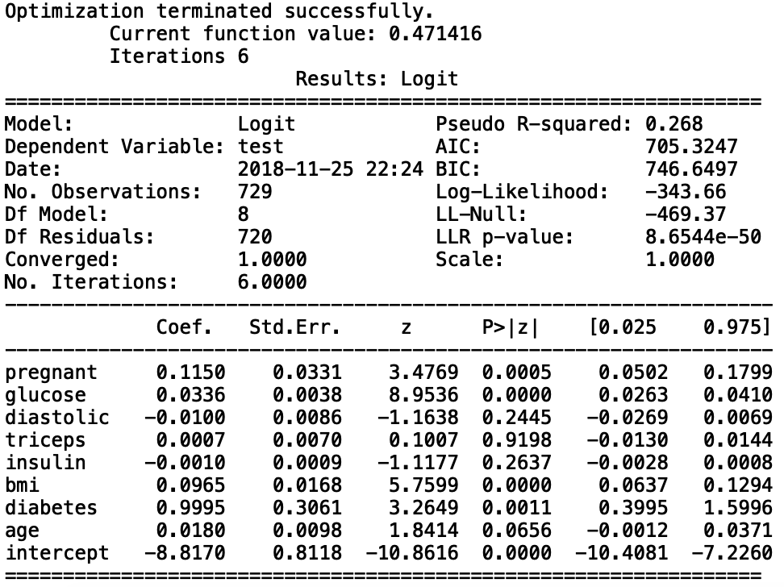

Logistic regression

```r
logit_model=sm.Logit(y,X)
result=logit_model.fit()
print(result.summary2())
```

## Backward Stepwise with BIC

Backward stepwise with BIC criterion, which involves starting with all candidate variables, testing the deletion of each variable using a chosen model fit criterion, deleting the variable (if any) whose loss gives the most BIC deterioration of the model fit, and repeating this process until no further variables can be deleted without a BIC loss of fit.

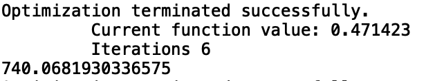

BIC after deleting triceps

```r
## Backward stepwise with BIC
# Triceps individually highly insignificant so drop the variable and assess the model
X1=X.drop(['triceps'], axis=1)
logit_model1=sm.Logit(y,X1)
result1=logit_model1.fit()
print(result1.bic)
```

The BIC of original model is 746, after deleting $triceps$, BIC declines to 740. We follow the same step and delete $diastolic$ and have the result as following:

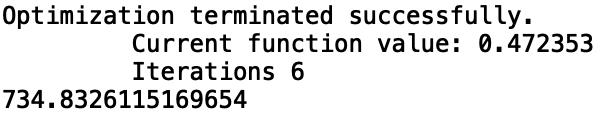

BIC after deleting triceps and diastolic

```r
# Drop diastolic (individually statistically insignificant) and assess the model
X2=X.drop(['triceps','diastolic'], axis=1)
logit_model2=sm.Logit(y,X2)
result2=logit_model2.fit()
print(result2.bic)
```

After deleting $diastolic$, BIC declines to 734. We follow the same step and delete $insulin$ and have the result as following:

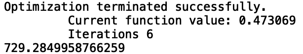

BIC after deleting triceps, diastolic and insulin

```r
# Drop insulin (indiviadually insignificant) and assess the model
X3=X.drop(['triceps','diastolic','insulin'], axis=1)
logit_model3=sm.Logit(y,X3)
result3=logit_model3.fit()
print(result3.bic)
```

After deleting $insulin$, BIC declines to 729. We now follow the same step and delete $age$ and finally have the model as:

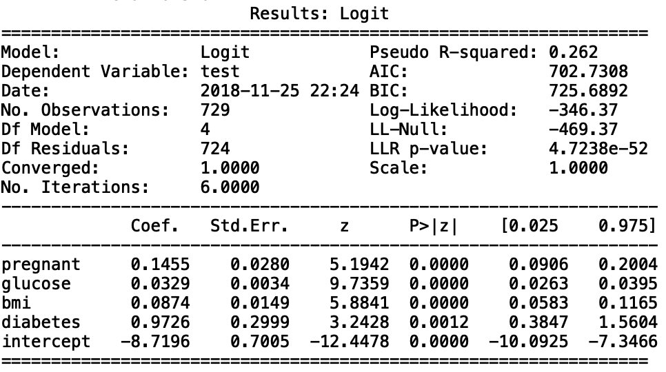

Logistic regression

```r
# Drop age (indiviadually insignificant) and assess the model
X4=X.drop(['triceps','diastolic','insulin', 'age'], axis=1)
logit_model4=sm.Logit(y,X4)
result4=logit_model4.fit()
print(result4.summary2())
```

We can find that the final model only contain 4 variables and intercept. All of them are statistically significant. The result above can be interpreted as following:
$$log \frac{p}{1-p} =-8.720+ 0.146 \times pregnant+ 0.033 \times glucose + 0.087 \times bmi+ 0.973 \times diabetes$$

## Model Fitting

In this part, we fit model with the model we derived in the last part.

```r
# Reset design matrix
X=X4.drop(['intercept'], axis=1)
# Fitting value
logreg = LogisticRegression()
logreg.fit(X, y)
```

We first calculate the accuracy of our classification model:

```r
# Fitting value
y_pred = logreg.predict(X)
print('Accuracy of logistic regression classifier on test set: {:.2f}'.format(logreg.score(X, y)))
```

## Confusion Matrix

```r
confusion_matrix = confusion_matrix(y, y_pred)
print(confusion_matrix)
```

[output not shown]

## Classification Report

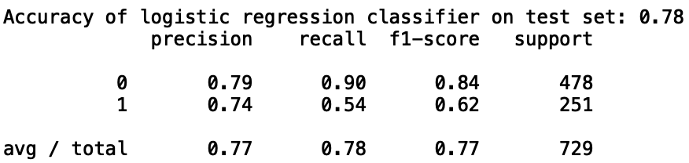

classification report

```r
# classification report
print(classification_report(y, y_pred))
```

## ROC Curve

When the prediction effect is good, the ROC curve is convex to the apex of the upper left corner. The diagonal line in the translation is tangent to the ROC curve to obtain a point where the TPR is large and the FPR is small. The better the model effect, the farther away the ROC curve is from the diagonal. In the extreme case, the ROC curve passes through the (0,1) point, that is, the positive example is all positive and the negative example is all negative. Under the ROC curve The area can quantitatively evaluate the effect of the model, which is recorded as AUC. The larger the AUC, the better the model effect.

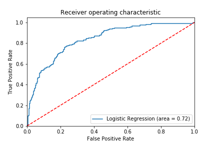

```r
# ROC curve
logit_roc_auc = roc_auc_score(y, logreg.predict(X))
fpr, tpr, thresholds = roc_curve(y, logreg.predict_proba(X)[:,1])
plt.figure()
plt.plot(fpr, tpr, label='Logistic Regression (area = %0.2f)' % logit_roc_auc)
plt.plot([0, 1], [0, 1],'r--')
plt.xlim([0.0, 1.0])
plt.ylim([0.0, 1.05])
plt.xlabel('False Positive Rate')
plt.ylabel('True Positive Rate')
plt.title('Receiver operating characteristic')
plt.legend(loc="lower right")
plt.savefig('Log_ROC')
plt.show()
```